# scRNA-seq Analysis of Real PBMC Data (10x Genomics) using Scanpy + PyTorch

Single-cell RNA sequencing (scRNA-seq) is a powerful technology that allows researchers to measure the gene expression profiles of individual cells. Unlike traditional bulk RNA sequencing, which averages the signals from thousands or millions of cells, scRNA-seq captures the unique transcriptome of each single cell, revealing cellular diversity, rare cell types, and dynamic biological processes within complex tissues. This enables detailed studies of development, disease progression, immune responses, and more, by uncovering how individual cells differ in their gene activity and function.

##### This workflow performs a complete single-cell RNA-seq (scRNA-seq) analysis using real PBMC (Peripheral Blood Mononuclear Cells) data from 10x Genomics. It uses:

```
Scanpy for preprocessing, visualization, clustering

PyTorch to build and train a deep autoencoder that learns a low-dimensional representation of gene expression

The learned features are then used for UMAP projection and Leiden clustering
```

# Important Python Packages for scRNA-seq Analysis

- **scanpy**: The main toolkit for single-cell RNA-seq analysis — handles data preprocessing, visualization, clustering, and more.
- **anndata**: Provides the core data structure (`AnnData`) for storing single-cell datasets efficiently — `scanpy` depends on it.
- **scikit-learn**: A general machine learning library used by Scanpy and for your own ML models (e.g., clustering, PCA).
- **matplotlib & seaborn**: Libraries for creating plots and visualizations of your data and analysis results.
- **umap-learn**: Implementation of UMAP dimensionality reduction, often used in scRNA-seq to visualize high-dimensional data in 2D or 3D.

```python
pip install scanpy anndata scikit-learn matplotlib seaborn umap-learn
```

[output not shown]

[output not shown]

# Load the dataset

```python
import scanpy as sc
import matplotlib.pyplot as plt

#load built-in dataset (PBMC)
adata = sc.datasets.pbmc3k()
adata
```

```
AnnData object with n_obs × n_vars = 2700 × 32738
    var: 'gene_ids'
```

```python
adata.shape
```

```
(2700, 32738)
```

```python
adata.obs.head()
```

[output not shown]

```python
import pandas as pd

df_expr = pd.DataFrame(adata.X.toarray(), index=adata.obs_names, columns=adata.var_names)
print(df_expr.shape)  # Should print (2700, 32738)
df_expr.head()
```

[output not shown]

[output not shown]

# Data Preprocessing and Quality Control

Before performing any downstream analysis on single-cell RNA-seq data, it is crucial to preprocess the raw data carefully to remove noise and artifacts that may bias the results. The first step is **quality control (QC)**, where cells with very few detected genes (less than 200) are filtered out. These low-quality cells often correspond to dead or dying cells or empty droplets that do not contain meaningful biological information. Similarly, genes that are expressed in fewer than 3 cells are removed because such lowly expressed genes are unlikely to provide robust signals for analysis and may introduce noise.

Next, the gene expression data is **normalized** so that differences in sequencing depth or capture efficiency between cells do not confound the interpretation. This is done by scaling each cell’s total counts to a fixed value (10,000 counts per cell) to make the data comparable across cells. After normalization, a **logarithmic transformation** (log1p) is applied to stabilize variance and reduce the impact of highly expressed genes, making the data distribution more symmetrical and suitable for downstream statistical analysis.

To focus the analysis on the most informative genes, we select **highly variable genes (HVGs)** based on their expression statistics. Genes with mean expression between 0.0125 and 3 and dispersion (variability) greater than 0.5 are retained. This step reduces the dimensionality of the data by keeping only genes that show meaningful biological variability across cells, which improves both computational efficiency and the quality of results.

Finally, the gene expression matrix is **scaled** so that each gene has zero mean and unit variance, with extreme values capped at 10 to limit the effect of outliers. Scaling standardizes the data for algorithms that assume normally distributed features, such as principal component analysis (PCA) and clustering methods.

Together, these preprocessing steps ensure that the scRNA-seq data is cleaned, normalized, and focused on biologically relevant features, laying a solid foundation for accurate downstream analyses such as dimensionality reduction, clustering, and cell type identification.

```python
# Quality control
sc.pp.filter_cells(adata, min_genes=200)
sc.pp.filter_genes(adata, min_cells=3)

# Normalize and log-transform
sc.pp.normalize_total(adata, target_sum=1e4)
sc.pp.log1p(adata)

# Highly variable genes
sc.pp.highly_variable_genes(adata, min_mean=0.0125, max_mean=3, min_disp=0.5)
adata = adata[:, adata.var.highly_variable]

# Scaling
sc.pp.scale(adata, max_value=10)
```

# Dimensionality Reduction and Visualization

After preprocessing the data, we apply **Principal Component Analysis (PCA)** to reduce the dimensionality of the gene expression matrix while preserving the most important sources of variation. PCA transforms the original high-dimensional data into a smaller set of orthogonal components (principal components) that capture the maximum variance in the data. Here, PCA is computed using the 'arpack' solver, which is efficient for large sparse datasets typical in single-cell RNA-seq. We visualize the first few principal components and color the cells based on the expression of an example gene, **CST3**, to explore how gene expression relates to the main axes of variation.

To further visualize the data in a low-dimensional space that captures local and global structures, we use **UMAP (Uniform Manifold Approximation and Projection)**. Before running UMAP, we compute the neighborhood graph of cells by finding the 10 nearest neighbors in the PCA space using the top 40 principal components. This graph encodes the local similarity between cells, which UMAP leverages to create a two-dimensional embedding that preserves both local neighborhoods and global relationships. The resulting UMAP plot is a powerful visualization tool that reveals clusters and patterns in the single-cell data. We color the UMAP embedding by the expression of several marker genes (**CST3**, **NKG7**, **PPBP**) to help interpret biological differences between cell populations.

Together, PCA and UMAP provide complementary approaches for reducing data complexity and visualizing cellular heterogeneity in scRNA-seq datasets, facilitating downstream tasks such as clustering and cell type annotation.

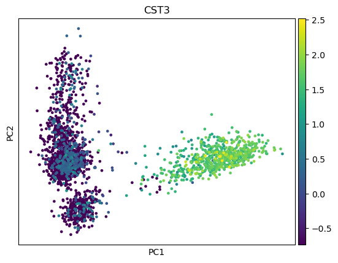

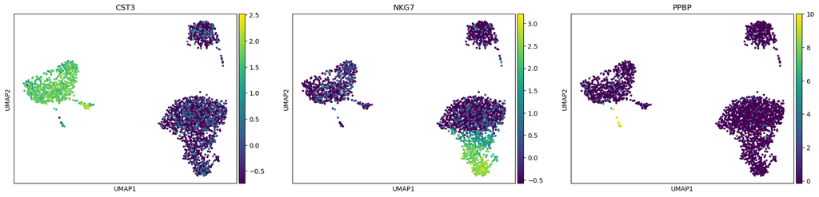

```python
# PCA
sc.tl.pca(adata, svd_solver='arpack')
sc.pl.pca(adata, color='CST3')  # Example gene

# UMAP
sc.pp.neighbors(adata, n_neighbors=10, n_pcs=40)
sc.tl.umap(adata)
sc.pl.umap(adata, color=['CST3', 'NKG7', 'PPBP'])
```

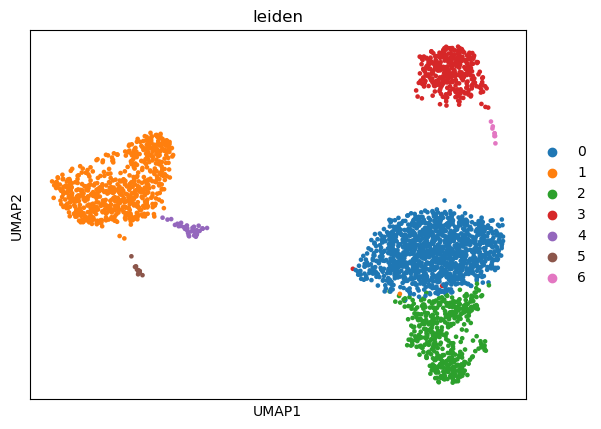

```python
sc.tl.leiden(adata, resolution=0.5)
sc.pl.umap(adata, color=['leiden'])
```

# Cell Type Classification using Random Forest

After clustering cells based on their gene expression profiles (e.g., using the Leiden algorithm), we can use machine learning to build a **classifier** that predicts the cluster (or cell type) of each cell based on its gene expression. Here, we use the **Random Forest** algorithm, a powerful ensemble learning method that constructs multiple decision trees and aggregates their predictions to improve accuracy and reduce overfitting.

First, we extract the gene expression matrix `X` as features and the cluster labels `y` (stored in `adata.obs['leiden']`) as target labels. The labels are converted to strings for compatibility with the classifier.

We split the dataset into a training set (80%) and a test set (20%) using `train_test_split`, ensuring that the classifier learns from one subset and is evaluated on unseen data to assess its generalization.

Next, we initialize the `RandomForestClassifier` with 100 trees (`n_estimators=100`) and train it on the training data (`X_train`, `y_train`). The trained model is then used to predict cluster labels for the test set (`X_test`), and the predictions (`y_pred`) are compared against the true labels (`y_test`).

Finally, we evaluate the classifier’s performance by calculating the **accuracy score**, which measures the fraction of correctly predicted cells, and printing a detailed **classification report** that includes precision, recall, and F1-score for each cluster. This evaluation helps us understand how well the classifier distinguishes different cell populations based on their gene expression signatures.

This approach provides a supervised learning method to classify cells and can be extended to annotate unknown cells or validate clustering results.

```python
from sklearn.ensemble import RandomForestClassifier
from sklearn.model_selection import train_test_split
from sklearn.metrics import accuracy_score, classification_report

# Extract features and labels
X = adata.X
y = adata.obs['leiden'].astype(str)

# Split the data
X_train, X_test, y_train, y_test = train_test_split(X, y, test_size=0.2, random_state=42)

# Train classifier
clf = RandomForestClassifier(n_estimators=100)
clf.fit(X_train, y_train)

# Predict
y_pred = clf.predict(X_test)

# Evaluate
print("Accuracy:", accuracy_score(y_test, y_pred))
print(classification_report(y_test, y_pred))
```

```
Accuracy: 0.9555555555555556
              precision    recall  f1-score   support

           0       0.96      0.98      0.97       262
           1       0.96      0.99      0.97       118
           2       0.91      0.88      0.89        77
           3       1.00      1.00      1.00        63
           4       1.00      0.40      0.57        10
           5       1.00      1.00      1.00         7
           6       0.00      0.00      0.00         3

    accuracy                           0.96       540
   macro avg       0.83      0.75      0.77       540
weighted avg       0.95      0.96      0.95       540
```

# Interpretation of Classification Results

The Random Forest classifier achieved an overall **accuracy of approximately 95.6%**, indicating that the model correctly predicted the cluster labels for about 96% of the test cells. This high accuracy suggests that the gene expression features used are informative and that the classifier is effective at distinguishing most cell populations.

Looking deeper into the **precision**, **recall**, and **F1-score** metrics for each cluster:

- **Precision** measures how many of the predicted cells for a cluster truly belong to that cluster.
- **Recall** measures how many of the actual cells from a cluster were correctly identified.
- **F1-score** is the harmonic mean of precision and recall, providing a balanced measure.

For most clusters (0, 1, 2, 3, and 5), the classifier shows high precision and recall, often above 0.9, indicating strong predictive performance. Cluster 3 and 5 even reached perfect scores, showing the model can confidently identify those cells.

However, clusters 4 and 6 present challenges:

- Cluster 4 has perfect precision (1.00) but low recall (0.40), meaning when the model predicts cluster 4, it is correct, but it misses many actual cluster 4 cells, possibly due to class imbalance or similar expression profiles with other clusters.
- Cluster 6 has zero precision, recall, and F1-score, indicating the classifier failed to correctly identify any cells from this cluster. This is likely due to the very small support (only 3 cells), which makes learning a reliable model for this cluster difficult.

The **support** column shows the number of test cells in each cluster, highlighting that smaller clusters (4, 5, 6) have less data, which can reduce classification performance.

The **macro average** (unweighted mean) scores are lower (0.77 F1-score) because they treat all classes equally, including small ones with poor performance. The **weighted average** accounts for class imbalance and is closer to overall accuracy (~0.95), reflecting strong performance on the majority of cells.

In summary, the classifier performs well overall but struggles with rare or small clusters, a common challenge in single-cell classification that might require additional data, feature engineering, or specialized methods to improve.

# Visualizing Top Genes by Feature Importance

To better understand which genes contribute most to the classification model’s decisions, we extract the **feature importances** from the trained Random Forest classifier. Feature importance scores reflect how much each gene influences the classification outcome, with higher values indicating greater importance.

We then select the top 20 genes with the highest importance scores by sorting the importance array and taking the indices corresponding to the largest values. These gene names are retrieved from the `adata.var_names` attribute, which stores the gene identifiers in the single-cell dataset.

Using the **Seaborn** library, we create a horizontal bar plot displaying these top 20 genes ranked by their importance scores. The plot helps visualize which genes are key drivers for distinguishing cell clusters, providing biological insight into marker genes that define different cell types or states.

This step is valuable not only for model interpretability but also for guiding further biological investigations by highlighting candidate genes that may play critical roles in cell identity or function.

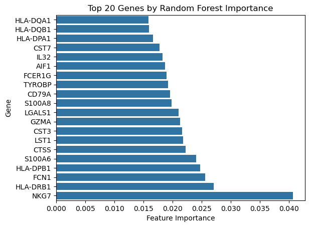

```python
import pandas as pd
import numpy as np
import seaborn as sns

# Top 20 genes by importance
importances = clf.feature_importances_
indices = np.argsort(importances)[-20:]
top_genes = adata.var_names[indices]

sns.barplot(x=importances[indices], y=top_genes)
plt.title('Top 20 Genes by Random Forest Importance')
plt.xlabel('Feature Importance')
plt.ylabel('Gene')
plt.show()
```

# Interpretation of Feature Importance Plot

This bar plot shows the **top 20 genes** ranked by their importance scores from the Random Forest classifier used to predict cell clusters. The x-axis represents the feature importance values, which quantify how much each gene contributed to making accurate predictions in the classification model.

From the plot, we can see that **NKG7** has the highest importance score, indicating it is the most influential gene in distinguishing between cell types in this dataset. Other highly important genes include **HLA-DRB1**, **FCN1**, and several genes from the HLA (human leukocyte antigen) family such as **HLA-DPB1**, **HLA-DQA1**, and **HLA-DQB1**.

These genes are often involved in immune responses, which aligns with the biological context of PBMC (peripheral blood mononuclear cells) data. Genes like **CST3**, **GZMA**, and **S100A6** also rank highly, suggesting their expression patterns are key markers for specific cell populations.

The feature importance scores provide insight into which genes the model relies on to differentiate clusters, potentially highlighting important biological markers that characterize immune cell subsets. This information can guide further biological interpretation and experimental validation.

```python
pip install torch scikit-learn scanpy
```

[output not shown]

[output cut: 88 more lines]

[output not shown]

[output not shown]

# Autoencoders

Autoencoders are a type of artificial neural network designed to learn efficient representations of data, typically for dimensionality reduction or feature learning. They consist of two main parts: an encoder, which compresses the input data into a lower-dimensional latent space, and a decoder, which reconstructs the original data from this compressed representation. During training, the network learns to minimize the difference between the input and its reconstruction, effectively capturing the most important features of the data. Autoencoders are widely used in applications such as data denoising, anomaly detection, and generative modeling.

### Explanation of the Code

- **Import libraries:**  
  The code imports essential libraries including PyTorch (`torch`) for deep learning, `scanpy` for single-cell RNA-seq data handling, `scikit-learn` for data scaling, and `matplotlib` for plotting.
- **Load dataset:**  
  The PBMC 3k dataset is loaded using `scanpy`. This dataset contains gene expression data from peripheral blood mononuclear cells.
- **Preprocessing steps:**
  - `normalize_total`: Normalizes each cell's total counts to a fixed target (10,000 here), making cells comparable.
  - `log1p`: Applies log-transform to reduce data skewness.
  - `highly_variable_genes`: Selects the top 1000 genes with the most variation across cells, focusing on important features.
  - Subsets the dataset to only include these highly variable genes.
- **Scaling:**  
  Converts the sparse matrix to a dense array and standardizes the features (genes) using `StandardScaler` to have zero mean and unit variance, improving neural network training.
- **Tensor conversion:**  
  Converts the scaled numpy array into a PyTorch tensor of type `float32` for model input.
- **Dataset and DataLoader:**  
  Wraps the tensor in a `TensorDataset` and then into a `DataLoader` for batching and shuffling during model training. The batch size is set to 128.

```python
import torch
import torch.nn as nn
from torch.utils.data import DataLoader, TensorDataset
from sklearn.preprocessing import StandardScaler
import scanpy as sc
import numpy as np
import matplotlib.pyplot as plt

# Load dataset
adata = sc.datasets.pbmc3k()
sc.pp.normalize_total(adata, target_sum=1e4)
sc.pp.log1p(adata)
sc.pp.highly_variable_genes(adata, n_top_genes=1000)
adata = adata[:, adata.var.highly_variable]

# Scale
X = adata.X.toarray()
scaler = StandardScaler()
X_scaled = scaler.fit_transform(X)

# Convert to tensor
X_tensor = torch.tensor(X_scaled, dtype=torch.float32)

# Dataset and DataLoader
dataset = TensorDataset(X_tensor)
dataloader = DataLoader(dataset, batch_size=128, shuffle=True)
```

### Explanation of the Autoencoder Class and Setup

- **Class definition:**  
  `Autoencoder` inherits from `torch.nn.Module` and defines a simple feedforward autoencoder network.
- **`__init__` method:**
  - Initializes the network layers.
  - The **encoder** compresses the input from `input_dim` to 512 neurons, applies ReLU activation, then further reduces to a 64-dimensional bottleneck layer representing the compressed latent space.
  - The **decoder** reconstructs the data by reversing this process: from 64 to 512 neurons, ReLU activation, then back to the original input dimension.
- **`forward` method:**  
  Defines the forward pass of the network, where input `x` is passed through the encoder to obtain the compressed representation, then through the decoder to reconstruct the input. It returns both the reconstructed output and the encoded representation.
- **Model, optimizer, and loss function setup:**
  - An instance of the autoencoder is created with the input dimension equal to the number of features in the dataset.
  - Adam optimizer is used with a learning rate of 0.001 to update the model parameters.
  - Mean Squared Error (`MSELoss`) is used as the reconstruction loss function, measuring the difference between the input and its reconstruction.

```python
class Autoencoder(nn.Module):
    def __init__(self, input_dim):
        super(Autoencoder, self).__init__()
        self.encoder = nn.Sequential(
            nn.Linear(input_dim, 512),
            nn.ReLU(),
            nn.Linear(512, 64)  # Bottleneck layer
        )
        self.decoder = nn.Sequential(
            nn.Linear(64, 512),
            nn.ReLU(),
            nn.Linear(512, input_dim)
        )

    def forward(self, x):
        encoded = self.encoder(x)
        decoded = self.decoder(encoded)
        return decoded, encoded

autoencoder = Autoencoder(input_dim=X_tensor.shape[1])
optimizer = torch.optim.Adam(autoencoder.parameters(), lr=1e-3)
loss_fn = nn.MSELoss()
```

### Explanation of the Training Loop

- **Epochs:**  
  The training runs for 20 epochs, meaning the entire dataset is passed through the model 20 times.
- **Batch training:**  
  For each batch of data from the `dataloader`:
  - Extract the batch data.
  - Reset the gradients in the optimizer with `optimizer.zero_grad()` to prevent accumulation.
  - Pass the batch through the autoencoder to get the reconstructed output.
  - Compute the reconstruction loss between the input and output using mean squared error (`loss_fn`).
  - Perform backpropagation with `loss.backward()` to compute gradients.
  - Update the model parameters with `optimizer.step()`.
  - Accumulate the batch loss to `total_loss`.
- **Progress printout:**  
  After each epoch, the total loss for that epoch is printed to monitor training progress and convergence.

```python
# Training
epochs = 20
for epoch in range(epochs):
    total_loss = 0
    for batch in dataloader:
        data = batch[0]
        optimizer.zero_grad()
        reconstructed, _ = autoencoder(data)
        loss = loss_fn(reconstructed, data)
        loss.backward()
        optimizer.step()
        total_loss += loss.item()
    print(f"Epoch {epoch+1}, Loss: {total_loss:.4f}")
```

```
Epoch 1, Loss: 21.5757
Epoch 2, Loss: 20.6101
Epoch 3, Loss: 20.3108
Epoch 4, Loss: 19.1389
Epoch 5, Loss: 18.5733
Epoch 6, Loss: 18.4207
Epoch 7, Loss: 18.1300
Epoch 8, Loss: 17.6802
Epoch 9, Loss: 17.5128
Epoch 10, Loss: 16.9871
Epoch 11, Loss: 16.7945
Epoch 12, Loss: 16.2975
Epoch 13, Loss: 15.9063
Epoch 14, Loss: 15.7161
Epoch 15, Loss: 15.3126
Epoch 16, Loss: 15.0282
Epoch 17, Loss: 14.8962
Epoch 18, Loss: 14.7510
Epoch 19, Loss: 14.4876
Epoch 20, Loss: 14.2292
```

### Explanation of Embedding Extraction and Downstream Analysis

- **Get encoded representations:**  
  Using `torch.no_grad()` to disable gradient tracking (since we are not training), the input tensor `X_tensor` is passed through the autoencoder to obtain the compressed embeddings from the bottleneck layer.
- **Add embeddings to AnnData:**  
  The embeddings (latent features) are converted from a PyTorch tensor to a NumPy array and stored in the AnnData object under `adata.obsm["X_deep"]`. This allows downstream analysis using the learned features.
- **Run UMAP and clustering:**
  - `sc.pp.neighbors`: Computes a neighborhood graph using the learned embeddings as the representation.
  - `sc.tl.umap`: Computes a 2D UMAP embedding for visualization.
  - `sc.tl.leiden`: Performs Leiden clustering on the neighborhood graph to identify groups of similar cells, with resolution controlling cluster granularity.
  - `sc.pl.umap`: Plots the UMAP visualization colored by Leiden cluster assignments.

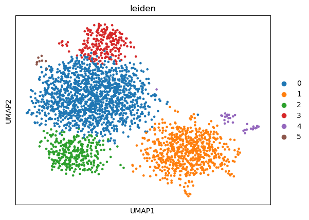

```python
# Get encoded representations
with torch.no_grad():
    _, embeddings = autoencoder(X_tensor)

# Add embeddings to AnnData
adata.obsm["X_deep"] = embeddings.numpy()

# Run UMAP and clustering on learned features
sc.pp.neighbors(adata, use_rep="X_deep")
sc.tl.umap(adata)
sc.tl.leiden(adata, resolution=0.5)
sc.pl.umap(adata, color=["leiden"])
```

### Explanation of the UMAP Plot Result

The UMAP plot visualizes the high-dimensional single-cell data in two dimensions using the learned features (embeddings) from the autoencoder. Each point represents a single cell, and the colors correspond to clusters identified by the Leiden algorithm.

### Conclusion

The autoencoder model was able to learn a compact and informative representation of the single-cell RNA-seq data. Using these learned features, the downstream clustering and visualization methods (UMAP and Leiden) identified clear and meaningful groupings of cells. This demonstrates the power of autoencoders for unsupervised feature extraction and dimensionality reduction in high-dimensional biological data, enabling better interpretation and analysis of complex cellular heterogeneity.